# AS2017367_Colombia

WAS Fernando

7/10/2020

```r
##loading the packages
library(coronavirus)
library(tidyverse)
library(magrittr)
coronavirus$cases <- abs(coronavirus$cases)
coronavirus <- as.data.frame(coronavirus, stringAsFactors = TRUE)
colombia_corona <- coronavirus %>% filter(country == "Colombia")

library(ggplot2)
library(maptools)
library(tibble)
library(tidyverse)
library(ggrepel)
library(png)
library(grid)
library(sp)
```

# Introduction

## Location of Colombia in World map

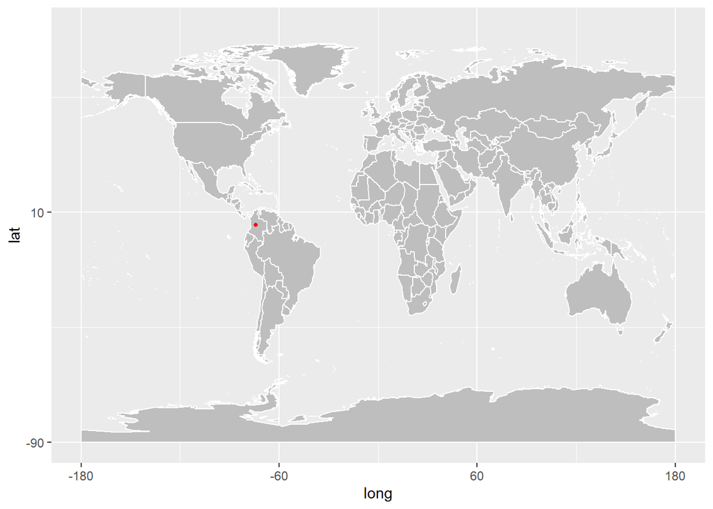

```r
data(wrld_simpl)

p <- ggplot() +
  geom_polygon(
    data = wrld_simpl,
    aes(x = long, y = lat, group = group), fill = "gray", colour = "white"
  ) +
  coord_cartesian(xlim = c(-180, 180), ylim = c(-90, 90)) +
  scale_x_continuous(breaks = seq(-180, 180, 120)) +
  scale_y_continuous(breaks = seq(-90, 90, 100))

p +
  geom_point(
    data = colombia_corona , aes(x = long, y = lat), color = "red", size
    = 1
  )
```

Colombia is a country in south America continent as shown above.

The COVID-19 pandemic in Colombia is part of the worldwide pandemic of coronavirus disease 2019 (COVID-19) caused by severe acute respiratory syndrome coronavirus 2 (SARS-CoV-2). The virus was confirmed to have reached Colombia on 6 March 2020. On 12 January 2020, the World Health Organization (WHO) confirmed that a novel coronavirus was the cause of a respiratory illness in a cluster of people in Wuhan City, Hubei Province, China, which was reported to the WHO on 31 December 2019. The case fatality ratio for COVID-19 has been much lower than SARS of 2003, but the transmission has been significantly greater, with a significant total death toll.

#### Climatic condition in Colombia

The Climate of Colombia is characterized for being tropical and isothermal as a result of its geographical location near the Equator presenting variations within five natural regions and depending on the altitude, temperature, humidity, winds and rainfall. Each region maintains an average temperature throughout the year only presenting variables determined by precipitation during a rainy season caused by the Intertropical Convergence Zone. The climates in Colombia are characterized for having tropical rainforests, savannas, steppes, deserts and mountain climate, mountain climate further divided into tierra caliente (hot land) tierra templada (temperate land) tierra fría (cold land), tierra helada (frozen land) and Páramo. Sometimes the weather of Colombia is altered by the seasons in northern hemisphere, for example, from March to June, the weather is mild Spring, from June to August the weather is hot Summer, From September to December the weather is cool Autumn, and from December to March the weather is cold Winter. This happens very rarely, and it is usually a slight difference.

The average temperature in colombia in the months February, March, April and May were 81, 81, 80 and 79 degrees Faranheit respectively.

#### Lockdown status of the country and actions taken by the country.

The virus was confirmed to have reached Colombia on 6 March 2020. As of 17 March, Colombia is denying entry to those who are not Colombian citizens, permanent residents or diplomats. AS of 14 March Colombia shut down all its border crossings with Venezuela. As of 17 March with the increase in the cases curfew which was previously applied only to the tourist city center from 10:00 p.m. to 4:00 am was extended to the whole city of Cartagena from 6:00 p.m. to 4:00 a.m. during weekdays, and for 24 hours during weekends. As of 17 March the first measure taken seeking the protection of the elderly is to decree mandatory isolation from 7:00 am on 20 March to 31 May for all adults over 70 years of age. On the evening of 20 March, President Iván Duque announced a 19-day nationwide quarantine, starting on 24 March at midnight and ending on 12 April at midnight then it was extended until 27 April. On 20 April, President Iván Duque announced a further extension of the nationwide lockdown until 11 May, but allowed the construction and manufacturing sectors to reopen starting from 27 April, under specific protocols.On 5 May, President Iván Duque announced a further extension of the nationwide lockdown for two weeks, until 25 May at midnight with certain measures for each group of people.

## Explotary Data analysis

```r
colombia_corona <- as.data.frame(colombia_corona)
head(colombia_corona)
```

```
        date province  country    lat     long      type cases
1 2020-01-22          Colombia 4.5709 -74.2973 confirmed     0
2 2020-01-23          Colombia 4.5709 -74.2973 confirmed     0
3 2020-01-24          Colombia 4.5709 -74.2973 confirmed     0
4 2020-01-25          Colombia 4.5709 -74.2973 confirmed     0
5 2020-01-26          Colombia 4.5709 -74.2973 confirmed     0
6 2020-01-27          Colombia 4.5709 -74.2973 confirmed     0
```

```r
tail(colombia_corona)
```

```
          date province  country    lat     long      type cases
331 2020-05-07          Colombia 4.5709 -74.2973 recovered   152
332 2020-05-08          Colombia 4.5709 -74.2973 recovered   124
333 2020-05-09          Colombia 4.5709 -74.2973 recovered   145
334 2020-05-10          Colombia 4.5709 -74.2973 recovered   136
335 2020-05-11          Colombia 4.5709 -74.2973 recovered   120
336 2020-05-12          Colombia 4.5709 -74.2973 recovered   146
```

```r
summary(colombia_corona)
```

```
      date              province           country
 Min.   :2020-01-22   Length:336         Length:336
 1st Qu.:2020-02-18   Class :character   Class :character
 Median :2020-03-17   Mode  :character   Mode  :character
 Mean   :2020-03-17
 3rd Qu.:2020-04-14
 Max.   :2020-05-12
      lat             long           type               cases
 Min.   :4.571   Min.   :-74.3   Length:336         Min.   :  0.00
 1st Qu.:4.571   1st Qu.:-74.3   Class :character   1st Qu.:  0.00
 Median :4.571   Median :-74.3   Mode  :character   Median :  0.00
 Mean   :4.571   Mean   :-74.3                      Mean   : 46.83
 3rd Qu.:4.571   3rd Qu.:-74.3                      3rd Qu.: 26.00
 Max.   :4.571   Max.   :-74.3                      Max.   :659.00
```

The table colombia_corona is consist of the no.of confirmed, death and recovered corona patients from jan 22 to May 2020 of the country Colombia and the location of the country in the worls map with its latitude and longitude.

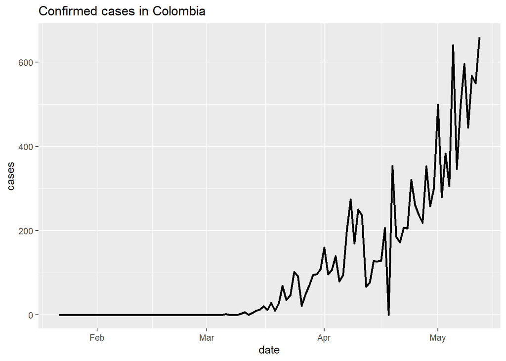

```r
confirmed_cases <- filter(colombia_corona, type == "confirmed")

ggplot(confirmed_cases,aes(x=date,y=cases)) + geom_path(size=1) + labs(title = "Confirmed cases in Colombia")
```

Above graph showas the confirmed no.of corona patients in Colombia in daily basis. It shows that no.of confirmed Corona patients has been increasing since mid of March upto mid of May althogh there are fluctions in the plot. This shows the lack of control of the situation.

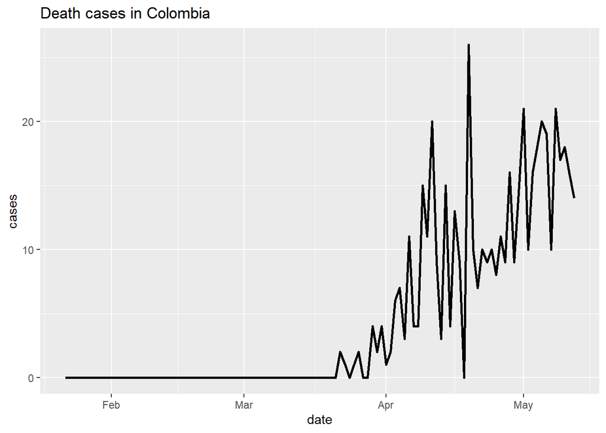

```r
death_cases <- filter(colombia_corona, type == "death")

ggplot(death_cases,aes(date, cases)) + geom_path(size=1) + labs(title = "Death cases in Colombia")
```

Above graph shows the no.of deadth from Corona in colombia in daily basis. This graph also shows that no.of death is increasing from end of March to mid of May. Although fluctuations shows that in some days no.of deaths are less than the previous day, still the no.of deaths per day has incresed than the previous week.

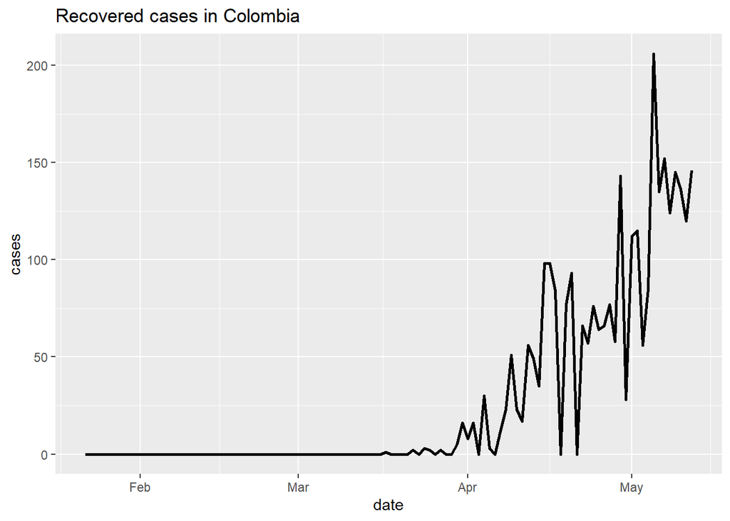

```r
recovered_cases <- filter(colombia_corona, type == "recovered")

ggplot(recovered_cases, aes(date, cases)) + geom_path(size=1) + labs(title = "Recovered cases in Colombia")
```

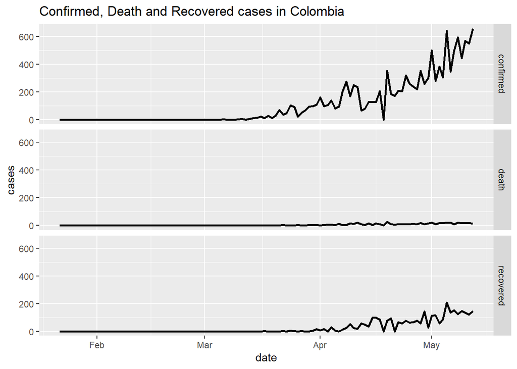

```r
ggplot(colombia_corona, aes(date, cases)) + geom_path(size=1) + facet_grid(rows = vars(type)) +
  labs(title = "Confirmed, Death and Recovered cases in Colombia")
```

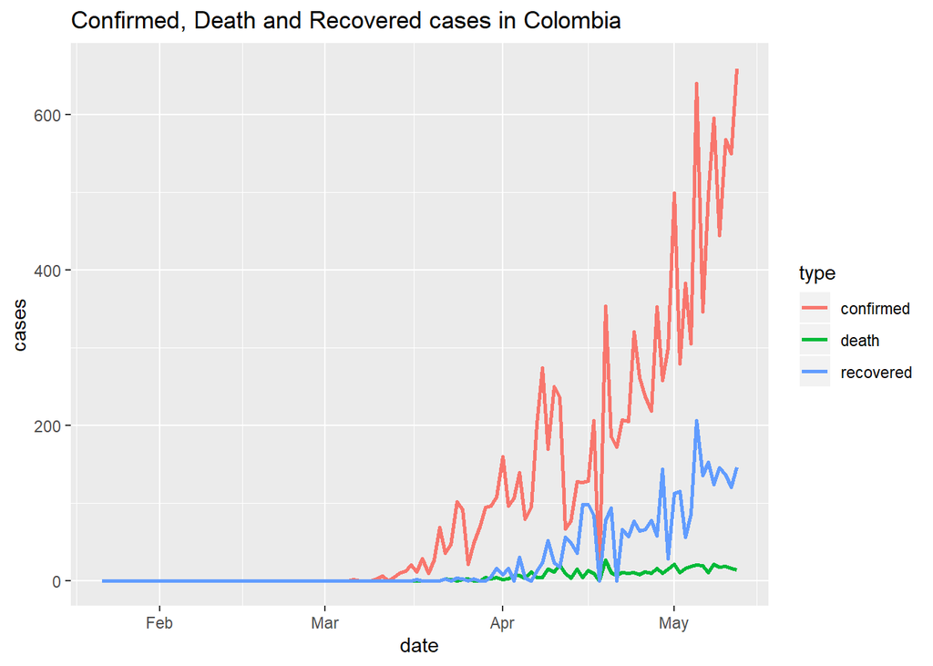

```r
ggplot(colombia_corona, aes(x = date, y = cases, colour = type)) + geom_path(size=1) +
  labs(title="Confirmed, Death and Recovered cases in Colombia")
```

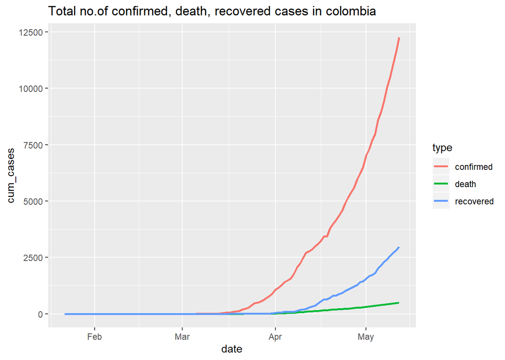

```r
colombia_corona <-  colombia_corona%>%
  group_by(type)%>%
  mutate(cum_cases = cumsum(cases))

ggplot(colombia_corona, aes(date, cum_cases, colour = type)) + geom_path(size = 1) +
  labs(title = "Total no.of confirmed, death, recovered cases in colombia")
```

Above graph implies that the total no.of confirmed cases has increased exponentially since mid of March. The increment of total no.of patients recovered from corona is not as total no.of patients confirmed with corona. There is a large gap between total no.of confirmed patiets with recovered patients therefore it can be concluded that still the country has to take measures to increase the medical facility in the country.

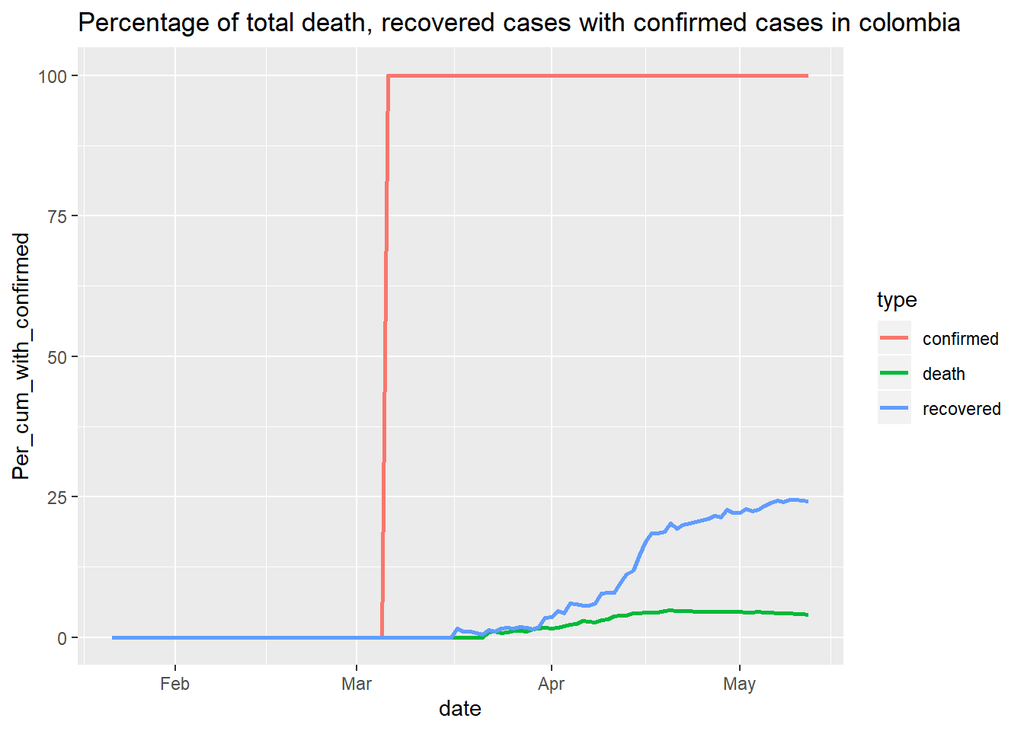

```r
colombia_corona_spread <- spread(select(colombia_corona, 1,6,8), key = type, value = cum_cases)

colombia_corona_spread$per_confirmed <- (colombia_corona_spread$confirmed / colombia_corona_spread$confirmed)*100
colombia_corona_spread$per_death <- (colombia_corona_spread$death / colombia_corona_spread$confirmed)*100
colombia_corona_spread$per_recovered <- (colombia_corona_spread$recovered / colombia_corona_spread$confirmed)*100

colombia_corona_gather <- gather(colombia_corona_spread, key = "type_1" , value = "Per_cum_with_confirmed",5:7)

colombia_corona <- cbind.data.frame(colombia_corona, select(colombia_corona_gather, 5,6))
colombia_corona[is.na(colombia_corona)] <- 0

ggplot(colombia_corona, aes(date, Per_cum_with_confirmed , colour = type)) + geom_path(size=1) +
  labs(title = "Percentage of total death, recovered cases with confirmed cases in colombia")
```

Above graph shows the total no.of death and recovered cases as a percentage of total confirmed cases in daily basis. This implies that percentage of total recovered patients with the total no.of confirmed cases is increasing daily but not in a satisfactory level. And also the percentage of total no.of death cases with total no.of confirmed cases is decreasing after increasing to about 5% which is satisfactory.

## Comapring with the countries in the same continent

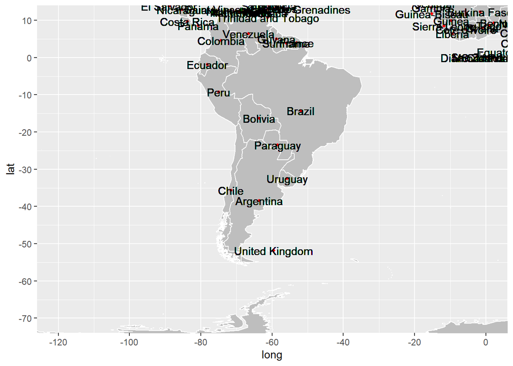

```r
coronavirus <- as.data.frame(coronavirus)

data(wrld_simpl)

p <- ggplot() +
  geom_polygon(
    data = wrld_simpl,
    aes(x = long, y = lat, group = group,), fill = "gray", colour = "white"
  ) +
  coord_cartesian(xlim = c(-120, 0), ylim = c(-70, 10)) +
  scale_x_continuous(breaks = seq(-120, 0,20)) +
  scale_y_continuous(breaks = seq(-70,10,10))


p +
  geom_point(
    data = coronavirus , aes(x = long, y = lat), color = "red", size
    = 1
  )  + geom_text(aes(x=coronavirus$long, y=coronavirus$lat, label=coronavirus$country))
```

The above plot shows the nearby countries to Colombia.

```r
nearcountries <- subset.data.frame(coronavirus, ( -60< lat & lat < 10) & (-90 < long & long < -50) )

count(nearcountries,country)
```

```
# A tibble: 16 x 2
   country            n
   <chr>          <int>
 1 Argentina        336
 2 Bolivia          336
 3 Brazil           336
 4 Chile            336
 5 Colombia         336
 6 Costa Rica       336
 7 Ecuador          336
 8 France           336
 9 Guyana           336
10 Panama           336
11 Paraguay         336
12 Peru             336
13 Suriname         336
14 United Kingdom   336
15 Uruguay          336
16 Venezuela        336
```

The above table shows the list of countries near Colombia.

```r
near_countries <- filter(coronavirus, country == "Argentina"|country =="Bolivia"|country =="Brazil"|
                           country =="Chile"|country =="Colombia"|country =="Costa Rica"|country =="Ecuador"|
                           country =="Guyana"|country =="Panama"|country =="Paraguay"|country =="Peru"|
                           country =="Suriname"|country =="Uruguay"|country =="Venezuela")
count(near_countries,country)
```

```
# A tibble: 14 x 2
   country        n
   <chr>      <int>
 1 Argentina    336
 2 Bolivia      336
 3 Brazil       336
 4 Chile        336
 5 Colombia     336
 6 Costa Rica   336
 7 Ecuador      336
 8 Guyana       336
 9 Panama       336
10 Paraguay     336
11 Peru         336
12 Suriname     336
13 Uruguay      336
14 Venezuela    336
```

From the countries near Colombia, the countries in the same continent which Colombia belong which is the continent South America has been sorted to a new data frame for further analysis.

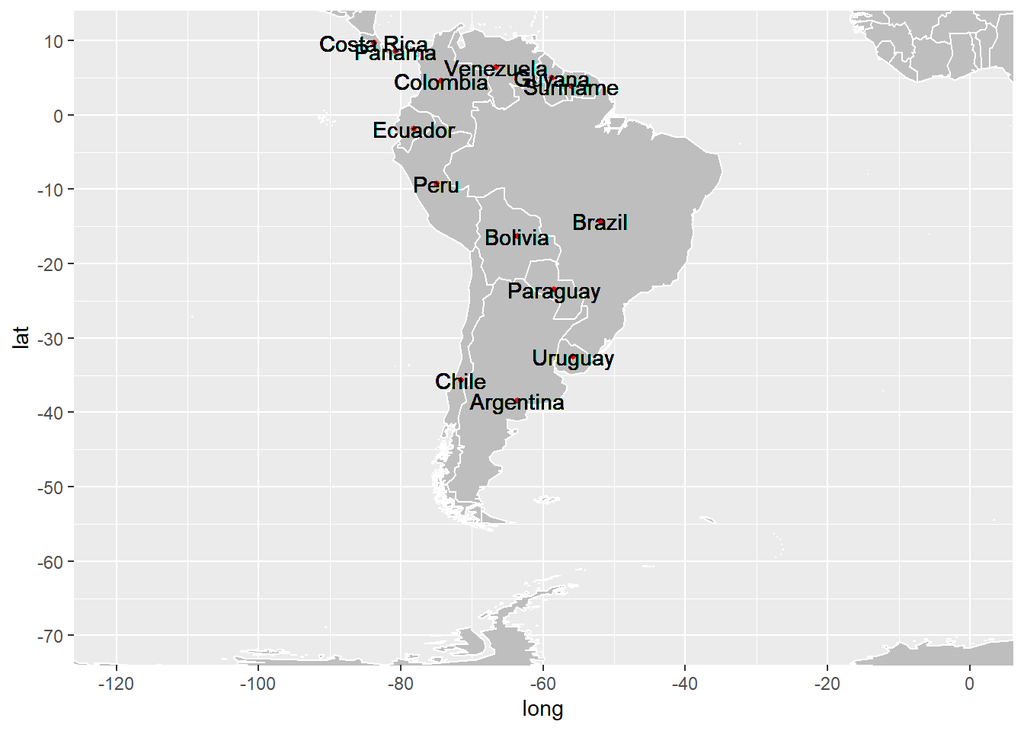

```r
p +
  geom_point(
    data = near_countries , aes(x = long, y = lat), color = "red", size
    = 1
  )  + geom_text(aes(x=near_countries$long, y=near_countries$lat, label=near_countries$country))
```

The above plot was generated in order to confirm whether all the conuntries in the south America Continent is in the relevent dataframe. Therefore it can be concluded that all the contries in the same continent has been considered.

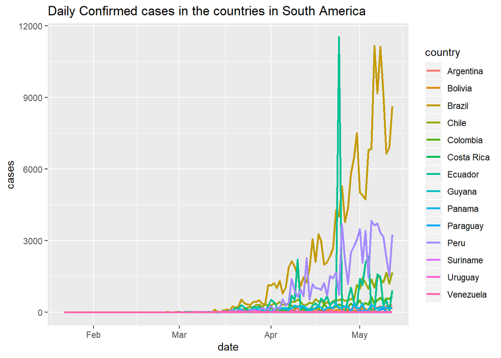

```r
confirmed_near_countries <- filter(near_countries, type == "confirmed")
death_near_countries <- filter(near_countries, type == "death")
recovered_near_countries <- filter(near_countries, type == "recovered")

ggplot(confirmed_near_countries, aes(x = date, y = cases, colour = country)) + geom_path(size=1) +
  labs(title="Daily Confirmed cases in the countries in South America")
```

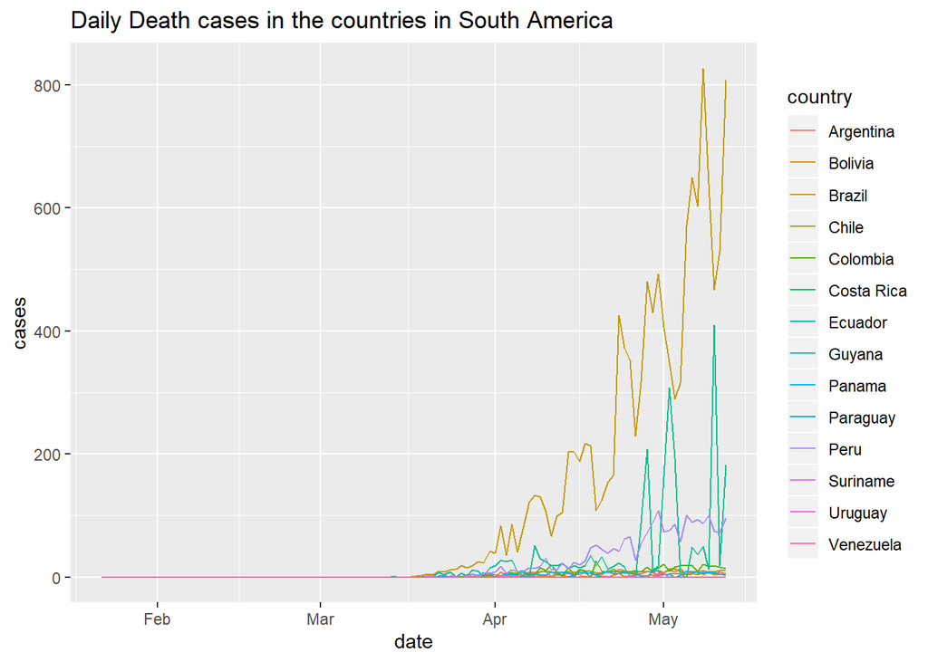

```r
ggplot(death_near_countries, aes(x = date, y = cases, colour = country)) + geom_path(size=0.5) +
  labs(title="Daily Death cases in the countries in South America")
```

Above graph also shows that even the daily death rate is high in Brazil and the death rate in Colombia is negligle when compared to other countries but it is effective if the prcentage of death rate with the total cases is compared.

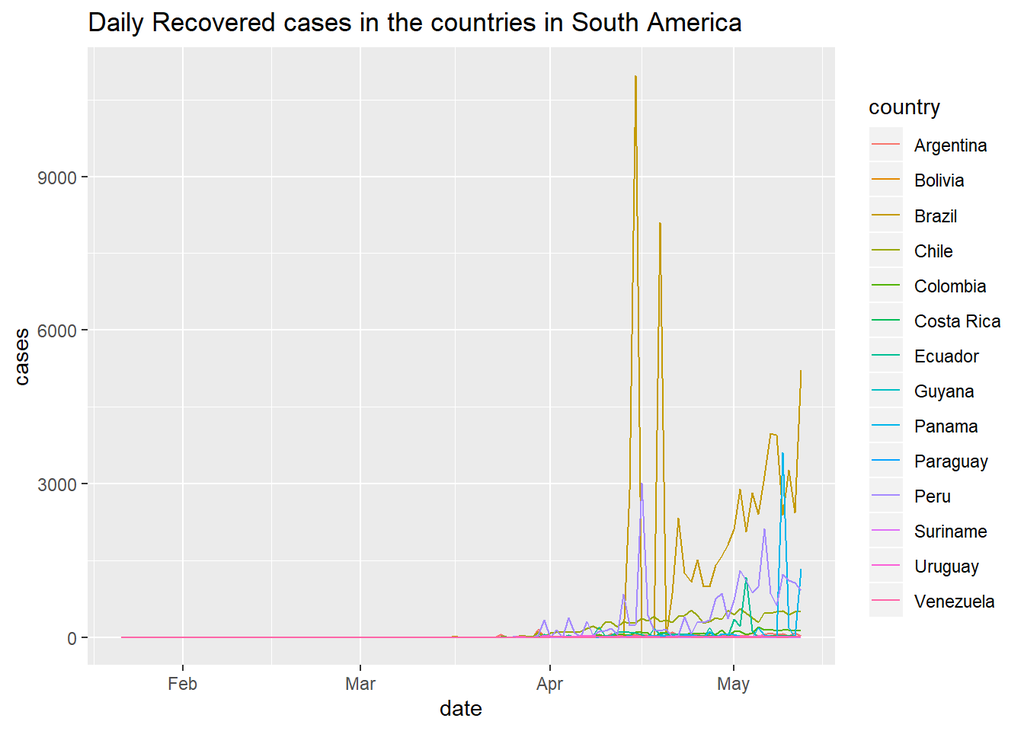

```r
ggplot(recovered_near_countries, aes(x = date, y = cases, colour = country)) + geom_path(size=0.5) +
  labs(title="Daily Recovered cases in the countries in South America")
```

Above graph also shows that even the daily recovered rate is high in Brazil and the death rate in Colombia is negligle when compared to other countries but it is effective if the prcentage of recovered rate with the total cases is compared.

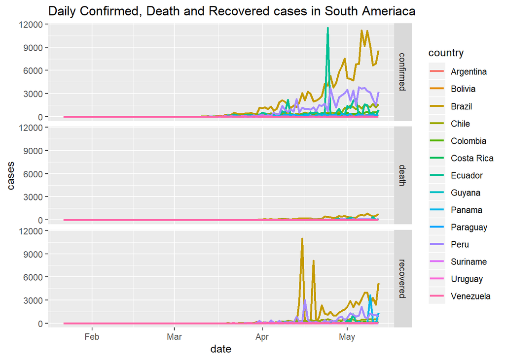

```r
ggplot(near_countries, aes(date, cases,colour = country)) + geom_path(size=1) + facet_grid(rows= vars(type)) +
  labs(title="Daily Confirmed, Death and Recovered cases in South Ameriaca")
```

It seems that the recovered rate of Brazil has increased rapidly but then increasing. And path of Colombia is negligable when compared to other countries.

```r
count(near_countries, type)
```

```
# A tibble: 3 x 2
  type          n
  <chr>     <int>
1 confirmed  1568
2 death      1568
3 recovered  1568
```

```r
near_countries <- near_countries%>%
  group_by(country,type)%>%
  mutate(cum_cases = cumsum(cases))
near_countries
```

```
# A tibble: 4,704 x 8
# Groups:   country, type [42]
   date       province country     lat  long type      cases cum_cases
   <date>     <chr>    <chr>     <dbl> <dbl> <chr>     <int>     <int>
 1 2020-01-22 ""       Argentina -38.4 -63.6 confirmed     0         0
 2 2020-01-23 ""       Argentina -38.4 -63.6 confirmed     0         0
 3 2020-01-24 ""       Argentina -38.4 -63.6 confirmed     0         0
 4 2020-01-25 ""       Argentina -38.4 -63.6 confirmed     0         0
 5 2020-01-26 ""       Argentina -38.4 -63.6 confirmed     0         0
 6 2020-01-27 ""       Argentina -38.4 -63.6 confirmed     0         0
 7 2020-01-28 ""       Argentina -38.4 -63.6 confirmed     0         0
 8 2020-01-29 ""       Argentina -38.4 -63.6 confirmed     0         0
 9 2020-01-30 ""       Argentina -38.4 -63.6 confirmed     0         0
10 2020-01-31 ""       Argentina -38.4 -63.6 confirmed     0         0
# ... with 4,694 more rows
```

Above graph shows the table with total cases relevent to each type and country in daily basis.

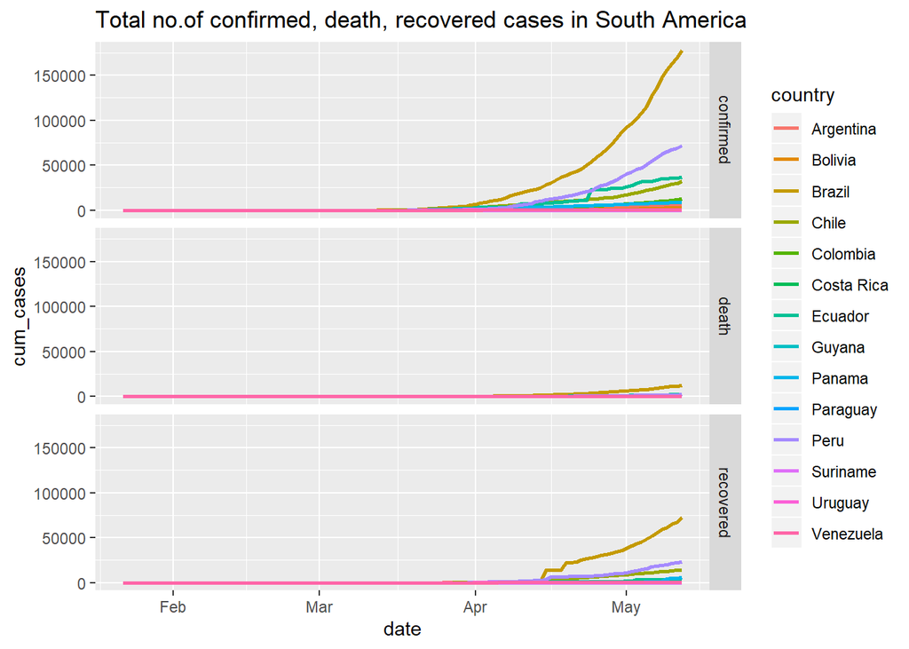

```r
ggplot(near_countries, aes(date,cum_cases, colour = country)) + geom_path(size=1) +
  facet_grid(rows= vars(type)) + labs(title = "Total no.of confirmed, death, recovered cases in South America")
```

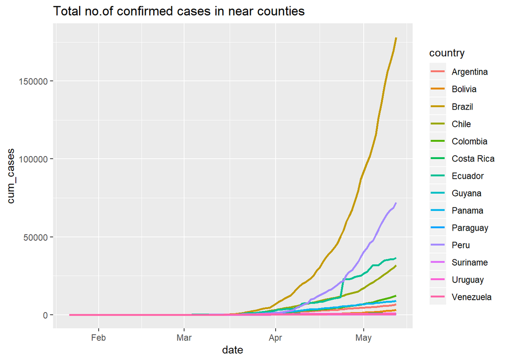

```r
ggplot(subset(near_countries,type == "confirmed"), aes(date,cum_cases, colour = country)) + geom_path(size=1) +
  labs(title = "Total no.of confirmed cases in near counties")
```

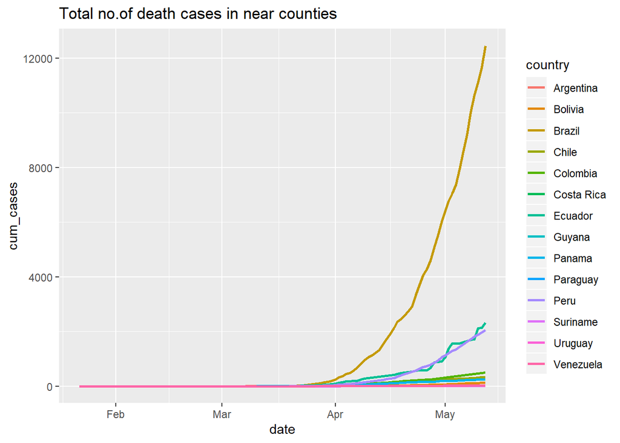

```r
ggplot(subset(near_countries,type == "death"), aes(date,cum_cases, colour = country)) + geom_path(size=1) +
  labs(title = "Total no.of death cases in near counties")
```

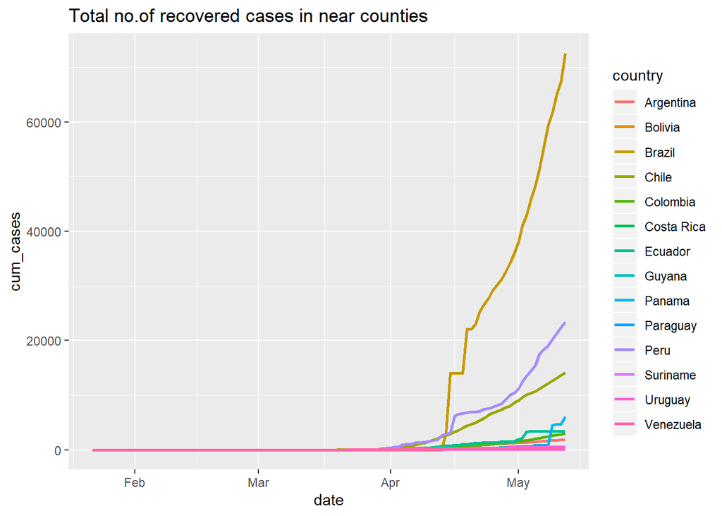

```r
ggplot(subset(near_countries,type == "recovered"), aes(date,cum_cases, colour = country)) + geom_path(size=1) +
  labs(title = "Total no.of recovered cases in near counties")
```

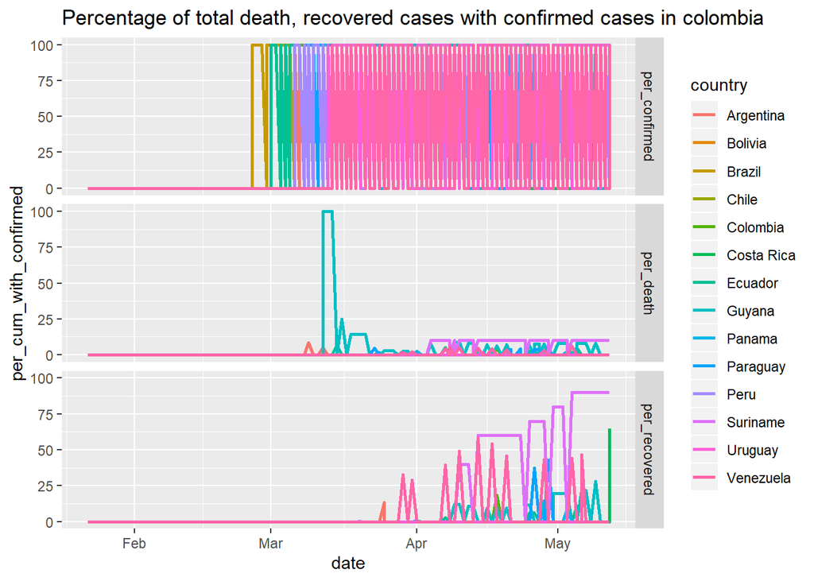

```r
near_countries_sub <- subset.data.frame(near_countries, select = -(7))

near_countries_spread <- spread(near_countries, key = type, value = cum_cases)

near_countries_spread$per_confirmed <- (near_countries_spread$confirmed/near_countries_spread$confirmed)*100
near_countries_spread$per_death <- (near_countries_spread$death/near_countries_spread$confirmed)*100
near_countries_spread$per_recovered <- (near_countries_spread$recovered/near_countries_spread$confirmed)*100

near_countries_gather <- gather(near_countries_spread, key = "type", value = "per_cum_with_confirmed", 10:12)

near_countries_gather[is.na(near_countries_gather)] <- 0


ggplot(near_countries_gather, aes(date, per_cum_with_confirmed , colour = country)) + geom_path(size=1) +
  labs(title = "Percentage of total death, recovered cases with confirmed cases in colombia") +
  facet_grid(rows= vars(type))
```

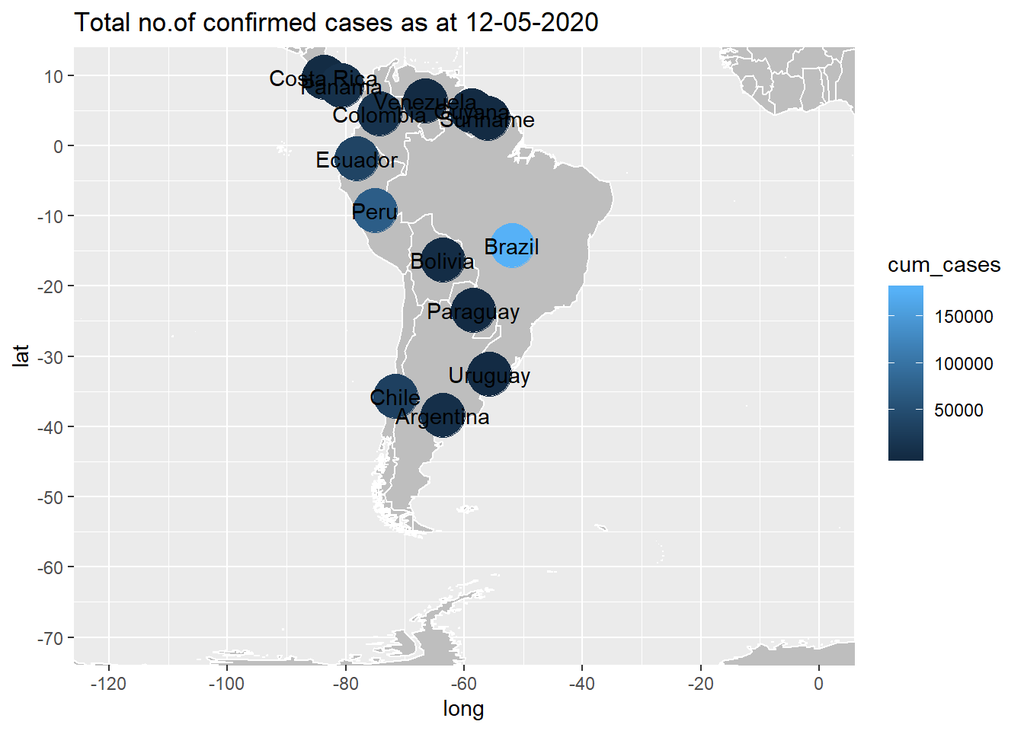

```r
corona_final <- filter(near_countries, date == "2020-05-12")

corona_final_confirmed <- filter(corona_final, type == "confirmed" )


p + geom_point(data = corona_final_confirmed, aes(x = long, y = lat, colour = cum_cases), size = 10) +
  geom_text(aes(x=corona_final_confirmed$long, y=corona_final_confirmed$lat, label=corona_final_confirmed$country)) +
  labs(title = "Total no.of confirmed cases as at 12-05-2020")
```

Above plot shows that Brazil has a high no.of confirmed corona cases where as colombia has a low no.of confirmed corona cases as at 12 the May 2020. And also it shows that apart from Brazil other nearby countries of colombia has a low no.of total confirmed corona patients.

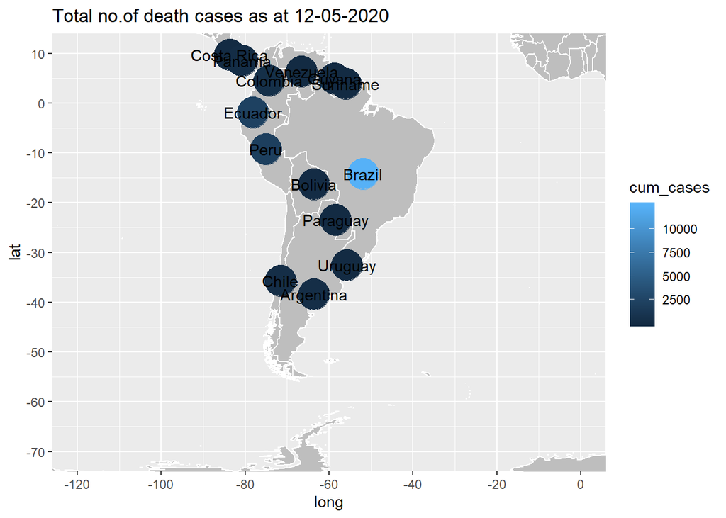

```r
corona_final_death <- filter(corona_final, type == "death" )

p + geom_point(data = corona_final_death, aes(x = long, y = lat, colour = cum_cases), size = 10) +
  geom_text(aes(x=corona_final_death$long, y=corona_final_death$lat, label=corona_final_death$country))+
  labs(title = "Total no.of death cases as at 12-05-2020")
```

Above plot shows that Brazil has a high no.of death corona cases where as colombia has a low no.of death corona cases as at 12 the May 2020. And also it shows that apart from Brazil other nearby countries of colombia has a low no.of total death cases.

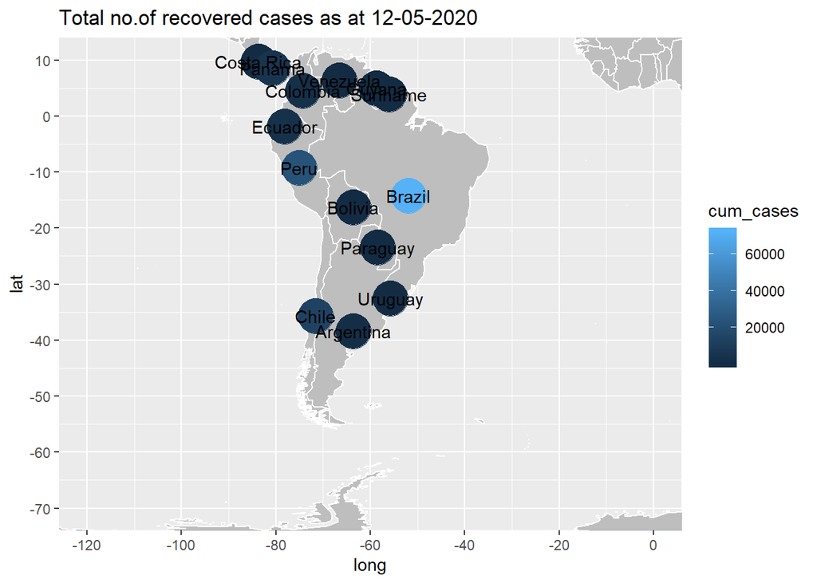

```r
corona_final_recovered <- filter(corona_final, type == "recovered" )

p + geom_point(data = corona_final_recovered, aes(x = long, y = lat, colour = cum_cases), size = 10) +
  geom_text(aes(x=corona_final_recovered$long, y=corona_final_recovered$lat, label=corona_final_recovered$country)) +
  labs(title = "Total no.of recovered cases as at 12-05-2020")
```

Above graph is also same as previous two which means Brazil has a high no.of recovered corona cases where as colombia has a low no.of recovered corona cases as at 12 the May 2020. And also it shows that apart from Brazil other nearby countries of colombia has a low no.of total recovered. This information is not better to compare therefore it is better to compare the perceantage values of total death and recovered cases with confirmed cases as at 12th May 2020 with nearby countries as below

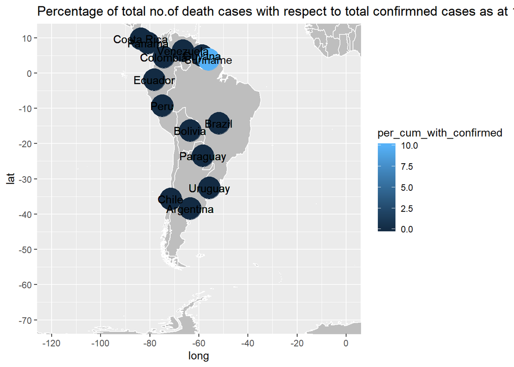

```r
corona_final_per <- filter(near_countries_gather, date == "2020-05-12")

corona_final_per_death <- filter(corona_final_per, type == "per_death")

p + geom_point(data = corona_final_per_death, aes(x = long, y = lat, colour = per_cum_with_confirmed), size = 10) +
  geom_text(aes(x=corona_final_per_death$long, y=corona_final_per_death$lat, label=corona_final_per_death$country)) +
  labs(title = "Percentage of total no.of death cases with respect to total confirmned cases as at 12-05-2020")
```

Above plot shows that although Brazil has high no.of total death cases but percetage with respect to the total confirmed cases it is low, but Suriname has high percentage of death cases with respect to its total confirmed cases which is about 10%. And Colombia also has very low death percentage.

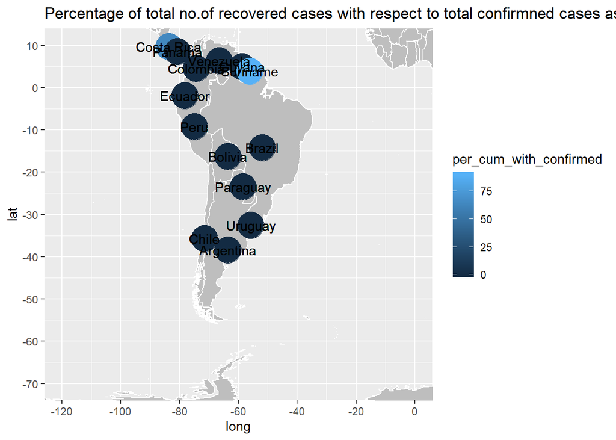

```r
corona_final_per_recovered <- filter(corona_final_per, type == "per_recovered")

p + geom_point(data = corona_final_per_recovered, aes(x = long, y = lat, colour = per_cum_with_confirmed), size = 10) +
  geom_text(aes(x=corona_final_per_recovered$long, y=corona_final_per_recovered$lat, label=corona_final_per_recovered$country)) +
  labs(title = "Percentage of total no.of recovered cases with respect to total confirmned cases as at 12-05-2020")
```

Above plot shows that although Brazil has a high no.of total recovered cases the percentage with its total no.of confirmed cases is very low where Suriname and Costa Rica has a high percentage of total recovered cases with respect to total confirmed cases. Colombia is also has a very low percentage of total recovered cases as at 12-05-2020.

## References

- R for Data Science by Hadley Wickham & Garrett Grolemund
- https://www.tutorialgateway.org/logical-operators-in-r/
- https://stackoverflow.com/questions/22038640/labeling-center-of-map-polygons-in-r-ggplot
- http://statseducation.com/Introduction-to-R/modules/tidy%20data/select/ http://www.sthda.com/english/wiki/reordering-data-frame-columns-in-r